# Enron POI Identification - Project

**Enron**, one of the largest US companies, collapsed into bankruptcy in 2002 due to widespread corporate fraud. As a result of the federal investigation, confidential information was made public, including emails and financial data for executives. We will build a POI (Person of Interest) identifier to extract individuals involved in the fraud from the data. We will use **`machine learning`** and **`sklearn`** to do so.

The email features in final_project_dataset.pkl are aggregated from the email dataset, and they record the number of messages to or from a given person/email address, as well as the number of messages to or from a known POI email address and the number of messages that have shared receipt with a POI.

Of the 146 people in the data set, there are 18 POIs. Using machine learning to identify the POIs is useful because of complexity of the data set. It allows us to try to find patterns to detect POIs. In this way, we can create a model that then may help us identify POIs from new data -- if a new person and their data are sent through the model, the model can then identify whether that new person may be a POI or not.

In this project I will build a person of interest identifier based on financial and email data made public as a result of the Enron scandal. I use email and financial data for 146 executives at Enron to identify persons of interest in the fraud case. A person of interest (POI) is someone who was indicted for fraud, settled with the government, or testified in exchange for immunity. This report documents the machine learning techniques used in building a POI identifier.

There are four major steps in my project:

- Enron dataset
- Feature processing
- Algorithm
- Validation

### Let's Start with the First Step

# Section 1 :Enron Dataset

```python
import sys
import pickle
sys.path.append("../tools/")
import pprint
from feature_format import featureFormat, targetFeatureSplit
from tester import dump_classifier_and_data,test_classifier

import numpy as np
import pandas as pd

import matplotlib.pyplot as plt
%matplotlib inline

import warnings
warnings.filterwarnings('ignore')
import seaborn as sns
```

```python
with open("final_project_dataset.pkl", "r") as data_file:
    data_dict = pickle.load(data_file) # this would the original copy of the data we are extracting.
df = pd.DataFrame.from_dict(data_dict, orient='index')
```

Let's look at our dataframe :-) By using DataFrames, we get amazing options to manipulate the data and use it for our tasks.  
Creation of plots are much easier using DataFrams than dictionaries.

```python
df.head()
```

|  | salary | to_messages | deferral_payments | total_payments | exercised_stock_options | bonus | restricted_stock | shared_receipt_with_poi | restricted_stock_deferred | total_stock_value | ... | loan_advances | from_messages | other | from_this_person_to_poi | poi | director_fees | deferred_income | long_term_incentive | email_address | from_poi_to_this_person |
| --- | --- | --- | --- | --- | --- | --- | --- | --- | --- | --- | --- | --- | --- | --- | --- | --- | --- | --- | --- | --- | --- |
| ALLEN PHILLIP K | 201955 | 2902 | 2869717 | 4484442 | 1729541 | 4175000 | 126027 | 1407 | -126027 | 1729541 | ... | NaN | 2195 | 152 | 65 | False | NaN | -3081055 | 304805 | phillip.allen@enron.com | 47 |
| BADUM JAMES P | NaN | NaN | 178980 | 182466 | 257817 | NaN | NaN | NaN | NaN | 257817 | ... | NaN | NaN | NaN | NaN | False | NaN | NaN | NaN | NaN | NaN |
| BANNANTINE JAMES M | 477 | 566 | NaN | 916197 | 4046157 | NaN | 1757552 | 465 | -560222 | 5243487 | ... | NaN | 29 | 864523 | 0 | False | NaN | -5104 | NaN | james.bannantine@enron.com | 39 |
| BAXTER JOHN C | 267102 | NaN | 1295738 | 5634343 | 6680544 | 1200000 | 3942714 | NaN | NaN | 10623258 | ... | NaN | NaN | 2660303 | NaN | False | NaN | -1386055 | 1586055 | NaN | NaN |
| BAY FRANKLIN R | 239671 | NaN | 260455 | 827696 | NaN | 400000 | 145796 | NaN | -82782 | 63014 | ... | NaN | NaN | 69 | NaN | False | NaN | -201641 | NaN | frank.bay@enron.com | NaN |

5 rows × 21 columns

```python
count = 1
for i in data_dict.keys()[:15]:
    print count," ", i
    count+=1

# We're having a look at first few entries in the data dictionary.
```

```
1   METTS MARK
2   BAXTER JOHN C
3   ELLIOTT STEVEN
4   CORDES WILLIAM R
5   HANNON KEVIN P
6   MORDAUNT KRISTINA M
7   MEYER ROCKFORD G
8   MCMAHON JEFFREY
9   HORTON STANLEY C
10   PIPER GREGORY F
11   HUMPHREY GENE E
12   UMANOFF ADAM S
13   BLACHMAN JEREMY M
14   SUNDE MARTIN
15   GIBBS DANA R
```

Let's understand how the data inside one entry of the dictionary looks.

```python
pprint.pprint (data_dict['BAXTER JOHN C'])
```

```
{'bonus': 1200000,
 'deferral_payments': 1295738,
 'deferred_income': -1386055,
 'director_fees': 'NaN',
 'email_address': 'NaN',
 'exercised_stock_options': 6680544,
 'expenses': 11200,
 'from_messages': 'NaN',
 'from_poi_to_this_person': 'NaN',
 'from_this_person_to_poi': 'NaN',
 'loan_advances': 'NaN',
 'long_term_incentive': 1586055,
 'other': 2660303,
 'poi': False,
 'restricted_stock': 3942714,
 'restricted_stock_deferred': 'NaN',
 'salary': 267102,
 'shared_receipt_with_poi': 'NaN',
 'to_messages': 'NaN',
 'total_payments': 5634343,
 'total_stock_value': 10623258}
```

Let's also explore what are the quantities of the Factors we're interested in.

```python
print 'Number of people:', df['poi'].count()
print 'Number of POIs:', df.loc[df.poi == True, 'poi'].count()
print 'Fraction of examples that are POIs:', \
    float(df.loc[df.poi == True, 'poi'].count()) / df['poi'].count()
print 'Number of features:', df.shape[1]
```

```
Number of people: 146
Number of POIs: 18
Fraction of examples that are POIs: 0.123287671233
Number of features: 21
```

```python
fpoi = open("poi_names.txt", "r")
rfile = fpoi.readlines()
poi = len(rfile[2:])
print "There were " + str(poi) + " poi's total."
```

```
There were 35 poi's total.
```

As it is visible from our above text file that the number of total POI's are 35 but for this project we are considering only 18 POI's

As visible from our DataFrame there are a lot of NaN values inside the DataFrame, lets count them.

```python
df.isnull().sum()
```

```
salary                       0
to_messages                  0
deferral_payments            0
total_payments               0
exercised_stock_options      0
bonus                        0
restricted_stock             0
shared_receipt_with_poi      0
restricted_stock_deferred    0
total_stock_value            0
expenses                     0
loan_advances                0
from_messages                0
other                        0
from_this_person_to_poi      0
poi                          0
director_fees                0
deferred_income              0
long_term_incentive          0
email_address                0
from_poi_to_this_person      0
dtype: int64
```

It seems that although the NaN's exist but they're not in a recognizable format. So let's make them recongnizable.

```python
df = df.replace('NaN', np.nan)
df.isnull().sum()
```

```
salary                        51
to_messages                   60
deferral_payments            107
total_payments                21
exercised_stock_options       44
bonus                         64
restricted_stock              36
shared_receipt_with_poi       60
restricted_stock_deferred    128
total_stock_value             20
expenses                      51
loan_advances                142
from_messages                 60
other                         53
from_this_person_to_poi       60
poi                            0
director_fees                129
deferred_income               97
long_term_incentive           80
email_address                 35
from_poi_to_this_person       60
dtype: int64
```

One important observation to be made here is **email features have same null count** for example,

- to_messages
- shared_receipt_with_poi
- from_messages
- from_this_person_to_poi
- from_poi_to_this_person  
  All share the same value 60 by which we can understand that there is some process that is causing the missing data is lack of email data for certain persons.

```python
df.info()
```

```
<class 'pandas.core.frame.DataFrame'>
Index: 146 entries, ALLEN PHILLIP K to YEAP SOON
Data columns (total 21 columns):
salary                       95 non-null float64
to_messages                  86 non-null float64
deferral_payments            39 non-null float64
total_payments               125 non-null float64
exercised_stock_options      102 non-null float64
bonus                        82 non-null float64
restricted_stock             110 non-null float64
shared_receipt_with_poi      86 non-null float64
restricted_stock_deferred    18 non-null float64
total_stock_value            126 non-null float64
expenses                     95 non-null float64
loan_advances                4 non-null float64
from_messages                86 non-null float64
other                        93 non-null float64
from_this_person_to_poi      86 non-null float64
poi                          146 non-null bool
director_fees                17 non-null float64
deferred_income              49 non-null float64
long_term_incentive          66 non-null float64
email_address                111 non-null object
from_poi_to_this_person      86 non-null float64
dtypes: bool(1), float64(19), object(1)
memory usage: 24.1+ KB
```

In case of the Financial data we found some redundancies. There were NaNs in the columns for financial data like bonus.  
So, the question that naturally arises here is why do NaNs exist there? To get a conclusion I explored the PDF document and I found out that the entries in few columns were missing, like bonus : it might be the case that the bonus might not be applicable. This view is supported by the insider pay pdf document in how the totals are calculated.  
So, finally I decided to replace all the NaNs in the financial features with zero.

```python
financial_features = ['salary', 'deferral_payments', 'total_payments', 'loan_advances', 'bonus', \
                      'restricted_stock_deferred', 'deferred_income', 'total_stock_value', 'expenses', \
                      'exercised_stock_options', 'other', 'long_term_incentive', 'restricted_stock', \
                      'director_fees']
df[financial_features] = df[financial_features].fillna(0)
df.isnull().sum()
```

```
salary                        0
to_messages                  60
deferral_payments             0
total_payments                0
exercised_stock_options       0
bonus                         0
restricted_stock              0
shared_receipt_with_poi      60
restricted_stock_deferred     0
total_stock_value             0
expenses                      0
loan_advances                 0
from_messages                60
other                         0
from_this_person_to_poi      60
poi                           0
director_fees                 0
deferred_income               0
long_term_incentive           0
email_address                35
from_poi_to_this_person      60
dtype: int64
```

As now we have explored the financial features of the dataset, lets do something about the email features as well.  
**I have intentionally segregated these two features so as to understand the variegatedness of the data we are having**

```python
email_features = ['to_messages', 'from_poi_to_this_person', 'from_messages', 'from_this_person_to_poi',\
                  'shared_receipt_with_poi']
```

```python
df[email_features] = df[email_features].fillna(df[email_features].median())
```

```python
df.isnull().sum()
```

```
salary                        0
to_messages                   0
deferral_payments             0
total_payments                0
exercised_stock_options       0
bonus                         0
restricted_stock              0
shared_receipt_with_poi       0
restricted_stock_deferred     0
total_stock_value             0
expenses                      0
loan_advances                 0
from_messages                 0
other                         0
from_this_person_to_poi       0
poi                           0
director_fees                 0
deferred_income               0
long_term_incentive           0
email_address                35
from_poi_to_this_person       0
dtype: int64
```

After processing the email features, I decided not to touch email address because it would be required for this project and also processing it would be out of scope for us in this project.

Let's Visualize some data and understand how Salary and Bonus are related.

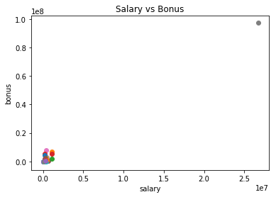

```python
features = ["salary", "bonus"]
#data_dict.pop('TOTAL', 0)
data = featureFormat(data_dict, features)
### plot features
for point in data:
    salary = point[0]
    bonus = point[1]
    plt.scatter( salary, bonus )

plt.xlabel("salary")
plt.ylabel("bonus")
plt.title("Salary vs Bonus")
```

```python
outlier = max(data,key=lambda item:item[1])
print (outlier)

my_dataset = data_dict # we keep our original data as it is for our reference and use a copy for modifications

for person in my_dataset:
    if my_dataset[person]['salary'] == outlier[0] and my_dataset[person]['bonus'] == outlier[1]:
        print "The outlier is : ",person
```

```
[ 26704229.  97343619.]
The outlier is :  TOTAL
```

So, from our above obsevation it is now clear that our outlier is the **"Total"** of all the other variables, so it has to be extremely large than that of any individual variable. Also it's of no use for us. It is the value at the end of our dataset which contains the sum of all the other values, so we would not use it.  
We are going to remove it from our dataset. And again observe what exactly is the situation of the scatter plot when it is not present.

Also, there is one problem in our dataset, upon observing the PDF we found that the entries for **`Eugene Lockhart`** I noticed that every single one of his features were either "NaN" or 0, so his information is completely useless.

```python
print "Before removing TOTAL length of our dataset is ",len(my_dataset)
```

```
Before removing TOTAL length of our dataset is  146
```

Also, I found one very interesting entry in our Dataset which either contains **0** or it contains **NaNs**

```python
my_dataset.pop('LOCKHART EUGENE E')
```

```
{'bonus': 'NaN',
 'deferral_payments': 'NaN',
 'deferred_income': 'NaN',
 'director_fees': 'NaN',
 'email_address': 'NaN',
 'exercised_stock_options': 'NaN',
 'expenses': 'NaN',
 'from_messages': 'NaN',
 'from_poi_to_this_person': 'NaN',
 'from_this_person_to_poi': 'NaN',
 'loan_advances': 'NaN',
 'long_term_incentive': 'NaN',
 'other': 'NaN',
 'poi': False,
 'restricted_stock': 'NaN',
 'restricted_stock_deferred': 'NaN',
 'salary': 'NaN',
 'shared_receipt_with_poi': 'NaN',
 'to_messages': 'NaN',
 'total_payments': 'NaN',
 'total_stock_value': 'NaN'}
```

SO, we're going to remove the above value from our dataset.

```python
my_dataset.pop('TOTAL',0)
my_dataset.pop('LOCKHART EUGENE E',0)
print "After removing TOTAL length of our dataset is ",len(my_dataset)
```

```
After removing TOTAL length of our dataset is  144
```

```python
data = featureFormat(my_dataset,features)
```

So, our outlier and useless data was removed as expected, now lets see what happens when we plot it again.

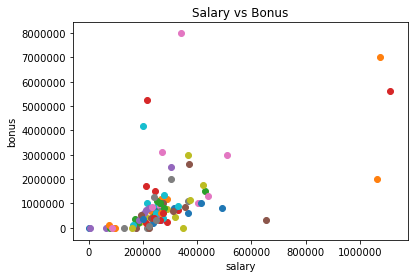

```python
for person in data:
    salary = person[0]
    bonus = person[1]
    plt.scatter(salary, bonus)

    plt.xlabel("salary")
    plt.ylabel("bonus")
    plt.title('Salary vs Bonus')
```

So, we have a very beautiful scatterplot depicting the variation of Salary and Bonus in a sensible manner having regularly separated entries.

```python
(df["salary"]).describe().apply(lambda x: format(x, '.2f'))
```

```
count         146.00
mean       365811.36
std       2203574.96
min             0.00
25%             0.00
50%        210596.00
75%        270850.50
max      26704229.00
Name: salary, dtype: object
```

```python
for person in my_dataset:
    if my_dataset[person]['salary'] != 'NaN' and my_dataset[person]['bonus'] != 'NaN' \
    and my_dataset[person]['salary'] >= 1000000 and my_dataset[person]['bonus'] >= 5000000:
        print person, 'Salary:', my_dataset[person]['salary'], 'Bonus:', my_dataset[person]['bonus']
```

```
LAY KENNETH L Salary: 1072321 Bonus: 7000000
SKILLING JEFFREY K Salary: 1111258 Bonus: 5600000
```

Two people who came out to have outlier values are :

- Kenneth L. Lay
- Jeffrey K. Skilling Let's find something more about them

```python
pprint.pprint (my_dataset['LAY KENNETH L'])
```

```
{'bonus': 7000000,
 'deferral_payments': 202911,
 'deferred_income': -300000,
 'director_fees': 'NaN',
 'email_address': 'kenneth.lay@enron.com',
 'exercised_stock_options': 34348384,
 'expenses': 99832,
 'from_messages': 36,
 'from_poi_to_this_person': 123,
 'from_this_person_to_poi': 16,
 'loan_advances': 81525000,
 'long_term_incentive': 3600000,
 'other': 10359729,
 'poi': True,
 'restricted_stock': 14761694,
 'restricted_stock_deferred': 'NaN',
 'salary': 1072321,
 'shared_receipt_with_poi': 2411,
 'to_messages': 4273,
 'total_payments': 103559793,
 'total_stock_value': 49110078}
```

```python
pprint.pprint (my_dataset['SKILLING JEFFREY K'])
```

```
{'bonus': 5600000,
 'deferral_payments': 'NaN',
 'deferred_income': 'NaN',
 'director_fees': 'NaN',
 'email_address': 'jeff.skilling@enron.com',
 'exercised_stock_options': 19250000,
 'expenses': 29336,
 'from_messages': 108,
 'from_poi_to_this_person': 88,
 'from_this_person_to_poi': 30,
 'loan_advances': 'NaN',
 'long_term_incentive': 1920000,
 'other': 22122,
 'poi': True,
 'restricted_stock': 6843672,
 'restricted_stock_deferred': 'NaN',
 'salary': 1111258,
 'shared_receipt_with_poi': 2042,
 'to_messages': 3627,
 'total_payments': 8682716,
 'total_stock_value': 26093672}
```

As visible, their salary and bonus values are above our defined outlier values. Digging more about them, we come to know that their positions are as follows:

- **Kenneth L. Lay, CEO**, and then Chairman of Enron Corporation
- **Jeffrey K. Skilling**, COO and then CEO of Enron Corporation

```python
df = df.drop('TOTAL')
```

```python
df = df.drop('LOCKHART EUGENE E')
```

## Here we are going to explore more about the financial features of our dataset.

```
144
```

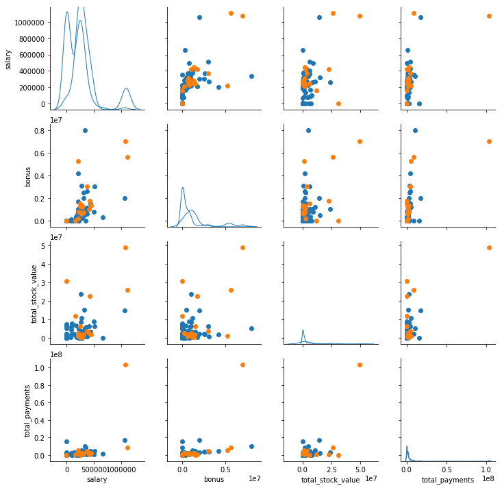

```python
g = sns.PairGrid(df, vars=['salary','bonus','total_stock_value','total_payments'],
                hue='poi')
g.map_lower(plt.scatter)
g.map_upper(plt.scatter)
g.map_diag(sns.kdeplot, lw=1)

len(df)
```

From this we can observe that the POI values and NON-POI values are distributed in what ways, in general they are mixed quite well with the regular data but sometimes we can observe the outliers of POI values.

Let's also explore the email features of our dataset, particularly the to_messages and from_messages features.

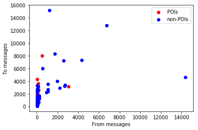

```python
pois = df[df.poi]
plt.scatter(pois.from_messages, pois.to_messages, c='red');
non_pois = df[~df.poi]
plt.scatter(non_pois.from_messages, non_pois.to_messages, c='blue');

plt.xlabel('From messages')
plt.ylabel('To messages')
plt.legend(['POIs', 'non-POIs'])
```

Here we find an outlier, which has value of from_messages more than 14,000. The outliers are the people those who send or recieve more emails than the average users. The next closest to the person who sent most of the email is near around 7000 and also there is one more point which is to the top left corner, so altogether 3 points which need to be identified are identified using the code below.

|  | salary | to_messages | deferral_payments | total_payments | exercised_stock_options | bonus | restricted_stock | shared_receipt_with_poi | restricted_stock_deferred | total_stock_value | ... | loan_advances | from_messages | other | from_this_person_to_poi | poi | director_fees | deferred_income | long_term_incentive | email_address | from_poi_to_this_person |
| --- | --- | --- | --- | --- | --- | --- | --- | --- | --- | --- | --- | --- | --- | --- | --- | --- | --- | --- | --- | --- | --- |
| KAMINSKI WINCENTY J | 275101.0 | 4607.0 | 0.0 | 1086821.0 | 850010.0 | 400000.0 | 126027.0 | 583.0 | 0.0 | 976037.0 | ... | 0.0 | 14368.0 | 4669.0 | 171.0 | False | 0.0 | 0.0 | 323466.0 | vince.kaminski@enron.com | 41.0 |
| KEAN STEVEN J | 404338.0 | 12754.0 | 0.0 | 1747522.0 | 2022048.0 | 1000000.0 | 4131594.0 | 3639.0 | 0.0 | 6153642.0 | ... | 0.0 | 6759.0 | 1231.0 | 387.0 | False | 0.0 | 0.0 | 300000.0 | steven.kean@enron.com | 140.0 |
| SHAPIRO RICHARD S | 269076.0 | 15149.0 | 0.0 | 1057548.0 | 607837.0 | 650000.0 | 379164.0 | 4527.0 | 0.0 | 987001.0 | ... | 0.0 | 1215.0 | 705.0 | 65.0 | False | 0.0 | 0.0 | 0.0 | richard.shapiro@enron.com | 74.0 |

3 rows × 21 columns

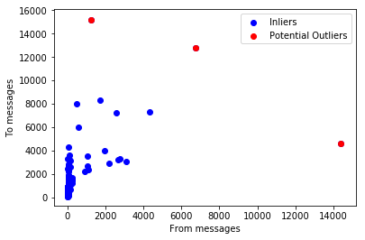

```python
# extracting the outlier points
outliers = df[np.logical_or(df.from_messages > 6000, df.to_messages > 10000)]

#plot them in red with the originals
plt.scatter(df.from_messages, df.to_messages, c='blue');
plt.scatter(outliers.from_messages, outliers.to_messages, c='red')
plt.xlabel('From messages')
plt.ylabel('To messages')
plt.legend(['Inliers', 'Potential Outliers'])

# Let's look at our outliers!
outliers
```

So now they've been identified.  
As far as my observations are concerned, I would say that these potential outliers do not really give us a lot of information to identify the POI.  
Why? It's likely that these points maybe generated due to an error or to be rational these points are not capturing the general trend of email usage but are instead most likely people in some special job position that requires them to do a lot of communication by email.  
The only thing to be noticed here is that these points are having values way above the average and it might affect our explorations and outcomes of the machine learning algorithms, so I would remove them.

```python
len(df)
```

```
144
```

```python
# removing the outlier candidates from the data set
df = df[df.from_messages < 6000]
```

```python
df = df[df.to_messages < 10000]
```

```python
len(df)
```

```
141
```

# Section 2 :Feature Processing

> Now we're ready to go ahead for our feature processing.

To Recap once again our features list is divided in 2 parts:

- Financial Features
- Email Features

### Let's begin with out first attempt to classify the dataset

Features we're going to explore would be our financial features. So let's begin

We are going to work with our data dictionary that we created above.

# Creating New Features

New features that we create are :

- networth : The sum **total of total_payments and total_stock_value**
- proportion_from_poi
- proportion_to_poi

```python
# Helper Functions
from sklearn.feature_selection import SelectKBest,f_classif
f_scores =[]

def proportionFromPOI(data_dict):
    for k, v in data_dict.iteritems():
    #Assigning value to the feature 'proportion_from_poi'
        if v['from_poi_to_this_person'] != 'NaN' and  v['from_messages'] != 'NaN':
            v['proportion_from_poi'] = float(v['from_poi_to_this_person']) / v['from_messages']
        else:
            v['proportion_from_poi'] = 0.0
    return (data_dict)

def proportionToPOI(data_dict):
    for k, v in data_dict.iteritems():
        #Assigning value to the feature 'proportion_to_poi'
        if v['from_this_person_to_poi'] != 'NaN' and  v['to_messages'] != 'NaN':
            v['proportion_to_poi'] = float(v['from_this_person_to_poi'] )/ v['to_messages']
        else:
            v['proportion_to_poi'] = 0.0
    return (data_dict)

def net_worth (data_dict) :
    features = ['total_payments','total_stock_value']
    for key in data_dict :
        name = data_dict[key]
        is_null = False

        for feature in features:
            if name[feature] == 'NaN':
                is_null = True
        if not is_null:
            name['net_worth'] = name[features[0]] + name[features[1]]
        else:
            name['net_worth'] = 'NaN'
    return data_dict

def select_features(features,labels,features_list,k=10) :
    clf = SelectKBest(f_classif,k)
    new_features = clf.fit_transform(features,labels)
    features_l=[features_list[i+1] for i in clf.get_support(indices=True)]
    f_scores = zip(features_list[1:],clf.scores_[:])
    f_scores = sorted(f_scores,key=lambda x: x[1],reverse=True)
    return new_features, ['poi'] + features_l, f_scores
```

```python
data_dict = net_worth(data_dict)
data_dict = proportionFromPOI(data_dict)
data_dict = proportionToPOI(data_dict)
pprint.pprint(data_dict['ALLEN PHILLIP K'])
```

```
{'bonus': 4175000,
 'deferral_payments': 2869717,
 'deferred_income': -3081055,
 'director_fees': 'NaN',
 'email_address': 'phillip.allen@enron.com',
 'exercised_stock_options': 1729541,
 'expenses': 13868,
 'from_messages': 2195,
 'from_poi_to_this_person': 47,
 'from_this_person_to_poi': 65,
 'loan_advances': 'NaN',
 'long_term_incentive': 304805,
 'net_worth': 6213983,
 'other': 152,
 'poi': False,
 'proportion_from_poi': 0.0214123006833713,
 'proportion_to_poi': 0.022398345968297727,
 'restricted_stock': 126027,
 'restricted_stock_deferred': -126027,
 'salary': 201955,
 'shared_receipt_with_poi': 1407,
 'to_messages': 2902,
 'total_payments': 4484442,
 'total_stock_value': 1729541}
```

```python
# we will add these features to our final_features and use it
final_features = []
final_features = financial_features
final_features+=['net_worth','proportion_from_poi','proportion_to_poi']
```

```python
my_dataset = data_dict
```

```python
data = featureFormat(my_dataset, final_features, sort_keys = True)
labels, features = targetFeatureSplit(data)
```

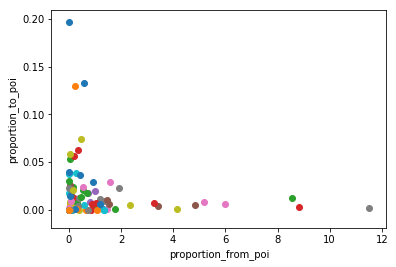

```python
for point in data_dict:
    salary = data_dict[point]["proportion_from_poi"]
    bonus = data_dict[point]["proportion_to_poi"]
    plt.scatter( salary, bonus)
plt.xlabel("proportion_from_poi")
plt.ylabel("proportion_to_poi")
plt.show()
```

# Section 3 : Algorithms

Using the helper function `select_features` we have selected our required features.  
`select_features` uses `SelectKBest` to select best features.

## Optimizing our algorithms, validating and evaluating metrics

```python
features,final_features,f_scores=select_features(features,labels,final_features,k=6)
# call the function with uses selectkbest
print ("features_list---" ,final_features)
print("feature scores")
for i in f_scores:
    print (i)
data = featureFormat(my_dataset, final_features, sort_keys = True)
labels, features = targetFeatureSplit(data)
```

```
('features_list---', ['poi', 'loan_advances', 'bonus', 'deferred_income', 'other', 'long_term_incentive', 'proportion_to_poi'])
feature scores
('loan_advances', inf)
('bonus', 772.43341185601332)
('other', 556.77730806873853)
('deferred_income', 287.2664203370756)
('long_term_incentive', 52.561787970591261)
('proportion_to_poi', 33.494255767406649)
('total_payments', 24.176713973334053)
('restricted_stock', 16.643636767803986)
('net_worth', 13.673228759023853)
('proportion_from_poi', 7.2097443906077103)
('deferral_payments', 2.7152382606791057)
('total_stock_value', 2.4765688698248112)
('expenses', 1.712424636015998)
('exercised_stock_options', 1.3179737674187317)
('director_fees', 0.12814399385851574)
('restricted_stock_deferred', 0.017226936204361963)
```

```python
print final_features
```

```
['poi', 'loan_advances', 'bonus', 'deferred_income', 'other', 'long_term_incentive', 'proportion_to_poi']
```

```python
from sklearn.naive_bayes import GaussianNB
clf = GaussianNB()
test_classifier(clf,my_dataset,final_features)
```

```
GaussianNB(priors=None)
	Accuracy: 0.75575	Precision: 0.25666	Recall: 0.24550	F1: 0.25096	F2: 0.24765
	Total predictions: 12000	True positives:  491	False positives: 1422	False negatives: 1509	True negatives: 8578
```

```python
from sklearn import tree
clf1=tree.DecisionTreeClassifier()
test_classifier(clf1,my_dataset,final_features)
```

```
DecisionTreeClassifier(class_weight=None, criterion='gini', max_depth=None,
            max_features=None, max_leaf_nodes=None,
            min_impurity_split=1e-07, min_samples_leaf=1,
            min_samples_split=2, min_weight_fraction_leaf=0.0,
            presort=False, random_state=None, splitter='best')
	Accuracy: 0.76292	Precision: 0.24836	Recall: 0.20850	F1: 0.22669	F2: 0.21541
	Total predictions: 12000	True positives:  417	False positives: 1262	False negatives: 1583	True negatives: 8738
```

```python
from sklearn.ensemble import AdaBoostClassifier
clf2 = AdaBoostClassifier()
test_classifier(clf2,my_dataset,final_features)
```

```
AdaBoostClassifier(algorithm='SAMME.R', base_estimator=None,
          learning_rate=1.0, n_estimators=50, random_state=None)
	Accuracy: 0.77008	Precision: 0.27897	Recall: 0.23950	F1: 0.25773	F2: 0.24648
	Total predictions: 12000	True positives:  479	False positives: 1238	False negatives: 1521	True negatives: 8762
```

```python
from sklearn.neighbors import KNeighborsClassifier
clf3=KNeighborsClassifier(n_neighbors = 4)
test_classifier(clf3,my_dataset,final_features)
```

```
Got a divide by zero when trying out: KNeighborsClassifier(algorithm='auto', leaf_size=30, metric='minkowski',
           metric_params=None, n_jobs=1, n_neighbors=4, p=2,
           weights='uniform')
Precision or recall may be undefined due to a lack of true positive predicitons.
```

```python
from sklearn.neighbors.nearest_centroid import NearestCentroid
clf4 = NearestCentroid()
test_classifier(clf4,my_dataset,final_features)
```

```
NearestCentroid(metric='euclidean', shrink_threshold=None)
	Accuracy: 0.82375	Precision: 0.36407	Recall: 0.07700	F1: 0.12712	F2: 0.09142
	Total predictions: 12000	True positives:  154	False positives:  269	False negatives: 1846	True negatives: 9731
```

# Section 4 : Validation

```python
from sklearn.cross_validation import train_test_split
features_train, features_test, labels_train, labels_test =     train_test_split(features, \
                                                    labels, test_size=0.3, random_state=42)
```

```python
'''
OUR FINAL ALGORITHM
'''
from time import time
from sklearn.pipeline import Pipeline
from sklearn.decomposition import PCA
from sklearn.grid_search import GridSearchCV, RandomizedSearchCV

t0 = time()

pipe1 = Pipeline([('pca',PCA()),('classifier',GaussianNB())])
param = {'pca__n_components':[4,5,6]}
gsv = GridSearchCV(pipe1, param_grid=param,n_jobs=2,scoring = 'f1',cv=2)
gsv.fit(features_train,labels_train)
clf = gsv.best_estimator_
print("GausianNB with PCA fitting time: %rs" % round(time()-t0, 3))
pred = clf.predict(features_test)

t0 = time()
test_classifier(clf,my_dataset,final_features,folds = 1000)
print("GausianNB  evaluation time: %rs" % round(time()-t0, 3))
```

```
GausianNB with PCA fitting time: 0.395s
Pipeline(steps=[('pca', PCA(copy=True, iterated_power='auto', n_components=4, random_state=None,
  svd_solver='auto', tol=0.0, whiten=False)), ('classifier', GaussianNB(priors=None))])
	Accuracy: 0.82500	Precision: 0.40775	Recall: 0.11050	F1: 0.17388	F2: 0.12936
	Total predictions: 12000	True positives:  221	False positives:  321	False negatives: 1779	True negatives: 9679

GausianNB  evaluation time: 2.693s
```

```python
'''
Adaboost tuned for comparision with final algorithm
'''
from sklearn.tree import DecisionTreeClassifier
abc = AdaBoostClassifier(random_state=40)
data = featureFormat(my_dataset, final_features, sort_keys = True)
labels, features = targetFeatureSplit(data)
dt = []
for i in range(6):
    dt.append(DecisionTreeClassifier(max_depth=(i+1)))
ab_params = {'base_estimator': dt,'n_estimators': [60,45, 101,10]}
t0 = time()
abt = GridSearchCV(abc, ab_params, scoring='f1_macro',)
abt = abt.fit(features_train,labels_train)
print("AdaBoost fitting time: %rs" % round(time()-t0, 3))
abc = abt.best_estimator_
t0 = time()
test_classifier(abc, data_dict, final_features, folds = 100)
print("AdaBoost evaluation time: %rs" % round(time()-t0, 3))
```

```
AdaBoost fitting time: 9.693s
AdaBoostClassifier(algorithm='SAMME.R',
          base_estimator=DecisionTreeClassifier(class_weight=None, criterion='gini', max_depth=3,
            max_features=None, max_leaf_nodes=None,
            min_impurity_split=1e-07, min_samples_leaf=1,
            min_samples_split=2, min_weight_fraction_leaf=0.0,
            presort=False, random_state=None, splitter='best'),
          learning_rate=1.0, n_estimators=60, random_state=40)
	Accuracy: 0.77917	Precision: 0.24806	Recall: 0.16000	F1: 0.19453	F2: 0.17223
	Total predictions: 1200	True positives:   32	False positives:   97	False negatives:  168	True negatives:  903

AdaBoost evaluation time: 24.718s
```

```python
dump_classifier_and_data(clf, my_dataset, final_features)
```

# Conclusions

We need to keep in mind that we dealt with a small, unbalanced dataset (an overwhelming majority of the dataset is comprised of non-POIs). This should make us cautious of our conclusions.

Although the scores are fine, and I didn't explore more from data features.

So there is a huge scope for more explorations in our project.

Maybe using deep learning we would be able to explore more relations and till now we could only explore 18 maybe we could explore all the 35 given in our file.

References :

- [1] : https://hadrien-lcrx.github.io
- [2] : https://github.com/karanthacker/Enron_Project/blob/master/poi_id.py
- [3] : https://github.com/shreym95/Enron-Fraud-POI-Identifier/blob/master/poi_id.py
- [4] : http://willemolding.github.io/IdentifyFraudEnron/
- [5] : https://github.com/Dalaska/Udacity-Enron-Fraud-Machine-Learning/blob/master/poi_id.py
- [6] : https://github.com/vishy730/Machine-Learning---Enron-Fraud-Email-Detection/blob/master/poi_id.py
- [7] : https://github.com/vishy730/Machine-Learning---Enron-Fraud-Email-Detection/blob/master/poi_id.py